# Primer on Animal Models

## Mixed effects models

For individual $i$ in group $j=1,\ldots, J$, a mixed effects model with $Z \subset X$:

$$Y_{ij} = X_{ij} \beta + Z_{ij}b_j + \epsilon_{ij},$$

The standard setup:

$b_j \sim^{iid} N(0, \Sigma_b) \perp \epsilon_{ij}$

```r
m1 <- brm(Y ~ (1|group), data = data)
```

## Animal Model

Now let us introduce across-group correlation between the coefficients by introducing a similarity matrix $\Psi$:

$b \sim N(0, \Sigma_b \otimes\Psi_{J \times J}) \perp \epsilon_{ij}.$

In Case Study 1 we used this strategy with $\Psi$ derived from the Graph Laplacian. These models are used in ecology (phylogenetics, animal breeding) and they go by the name *animal model*.

```r
m1 <- brm(Y ~ (1|group), data = data, cov_ranef = list(group = Psi))
```

## Heritability

Let $Y$ be a phenotype (variable of interest) in population $P$.

The variance of $Y$ splits into three components:

$$V_Y= \underbrace{V_E}_{\textrm{Environmental}} + \underbrace{V_{A}}_{\textrm{Genetic Additive}} + \underbrace{V_{NA}}_{\textrm{Genetic Non-Additive}},$$

The *heritability* $h^2$ of $Y$ in population $P$ is

$$h^2 = \frac{V_A}{V_Y},$$
and the *breeding value* of individual $i$ is

$$(Y_{ij}- \bar{Y})h^2.$$

- Breeding value tells us the value of using subject $i$ as a parent if we are interested in producing offsprings with higher value of $Y$.

## Heritability

- Can be obtained as the regression coefficient of parent-offspring regression:

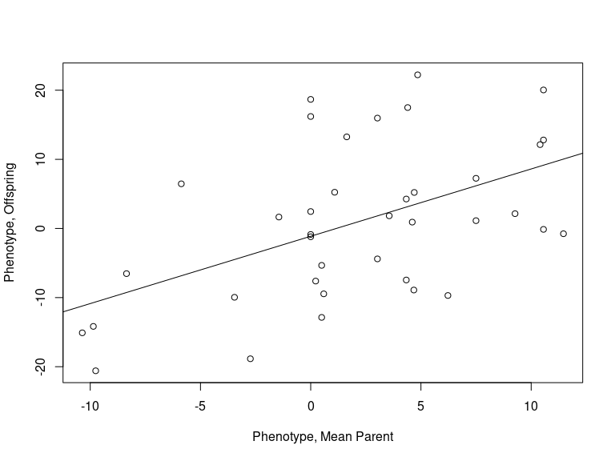

## The pedigree matrix

The similarity matrix $\Psi$ is obtained as follows: List the animals $a_i= a_1,\ldots, a_N$ monotonically by generations. For $j \le i$, and parents $p_1[i],p_2[i]$.

If both $p_1[i], p_2[i]$ are observed: $\Psi_{i,j} = \Psi_{j,i} = \frac{1}{2} ( \Psi_{j, p_1[i]} + \Psi_{j, p_2[i]} )$ and $\Psi_{i,i} = 1 + \frac{1}{2} \Psi_{p_1[i],p_2[j]}$.

If only $p_1[i]$ is observed:

$\Psi_{i,j} = \Psi_{j,i} = \Psi_{j, p_1[i]}$, $\Psi_{i,i}=1$.

Otherwise:

$\Psi_{i,j}=\Psi_{j,i}=0$ and $\Psi_{i,i}=1$.

## The pedigree matrix

R can do this automatically:

```r
Pedigree[1:10,]
```

```
##    Individual SIRE DAM
## 1           1   NA  NA
## 2           2   NA  NA
## 3           3   NA  NA
## 4           4   NA  NA
## 5           5    1   2
## 6           6    1   2
## 7           7    3   4
## 8           8    3   4
## 9           9    5   8
## 10         10    7   6
```

```r
inv.Psi <- MCMCglmm::inverseA(Pedigree)
Psi <- solve(inv.Psi$Ainv)
rownames(Psi) <- rownames(inv.Psi$Ainv)
```

## Fitting the models

$$P_{i} = \beta_0 + b_i + \epsilon_i,$$
$$\epsilon_i \sim^{iid} N(0, \sigma^2) \perp b \sim N(0, \sigma_b^2\Psi),$$
where $\Psi$ is the pedigree matrix

```r
m1 <- brm(Phenotype ~ (1|Individual), data = data,
          family = "gaussian", cov_ranef = list(Individual = Psi), control = list(adapt_delta = 0.99), prior = c(brms::prior(normal(0, 1), class = Intercept),
                            brms::prior(cauchy(0, 1), class = sd),
                            brms::prior(cauchy(0, 1), class = sigma)),warmup = 6000, iter = 26000)
```

- With this setup, the random effects $b_i$ are the breeding values.
- Heritability $h^2$ is obtained by $\frac{\sigma_b^2}{\sigma_b^2+\sigma^2}$
- In this example we have only one predictor in the model, but can and should use all the data we have

## Takeaways

- Now that you know mixed effects models you can with very modest effort do animal models
- This kind of thinking can be applied elsewhere
- brms can do this easily, but lm4 can not. There are many other packages in R that can do that in frequentist setting

## Acknowledgements & Reading:

- Slide layout: Amy Herring, STA410/STA610 Fall 2019, Duke University
- Code for automatically getting pedigree matrix: https://github.com/JonBrommer/Multivariate-Mixed-Models-in-R/wiki/brms-examples
- More on animal models: Guilherme J. M. Rosa: https://www.biostat.washington.edu/sites/default/files/modules/Seattle-SISG-18-MM-Lecture04.pdf
- de Villemereuil, Gimenez, Doligez: Comparing parent-offspring regression with frequentist and Bayesian animal models to estimate heritability in wild populations: A simulation study for Gaussian and binary traits, Methods in Ecology and Evolution 2013